# Lab 10: API

Shuying Yu

3/10/2022

```r
knitr::opts_chunk$set(echo = TRUE, warning = FALSE, message = FALSE)

#Attach packages in specific order

library(sf) #work with shape file
library(raster) #work with spatial data
library(rnaturalearth) #website for spatial data or maps you can use for free
library(tidyverse)
library(jsonlite) #use API access
library(here)
```

Temporary ICN key: 9bb4facb6d23f48efbf424bb05c0c1ef1cf6f468393bc745d42179ac4aca5fee

Etiquette for API:

- they will provide service to give data, maintained in R servers which can be expensive
- make sure to put pause in loops (e.g., purrr), to prevent from crashing the server

In console: usethis::edit_r_environ() and add key, need to restart R

# Accessing IUCN API

https://apiv3.iucnredlist.org/api/v3/docs

- Under “species by Country”, paste in data for that URL: “/api/v3/country/getspecies/:country?token=‘YOUR TOKEN’”
- To get species, need to tell what country you want, TOKEN, etc

```r
#Get environ from system
api_key <- Sys.getenv("IUCN_KEY")
```

# Get IUCN Redlist Version

version endpoint: /api/v3/version

```r
domain_name <- "http://apiv3.iucnredlist.org"

#Drop leading slash
version_end <- "api/v3/version"

#Stick together as URL
#file.path like here, but takes character strings and put slashes in between
version_url <- file.path(domain_name, version_end)



#Copy and paste into browser to check version, but we can do it here
#List of 1 element
api_version <- jsonlite::fromJSON(version_url)

api_version$version
```

```
## [1] "2021-3"
```

# Count of how many species (spp) have been assessed

/api/v3/speciescount?token=‘YOUR TOKEN’

```r
#Format string fpr sprintf function
#Assembles formatted text
count_stem <- "api/v3/speciescount?token=%s"

#api_key is what goes into %s
#Replaced with API token
count_end <- sprintf(count_stem, api_key)

#Assemble URL
count_url <- file.path(domain_name, count_end)

#Species count
spp_count <- fromJSON(count_url)
```

All the mammals, reptiles, plants, but less for marine species

# Get a page of results

Species come in pages of 10k at a time, but can get loop for 1 set of 10k, then another set of 10k.

/api/v3/species/page/:page_number?token=‘YOUR TOKEN’

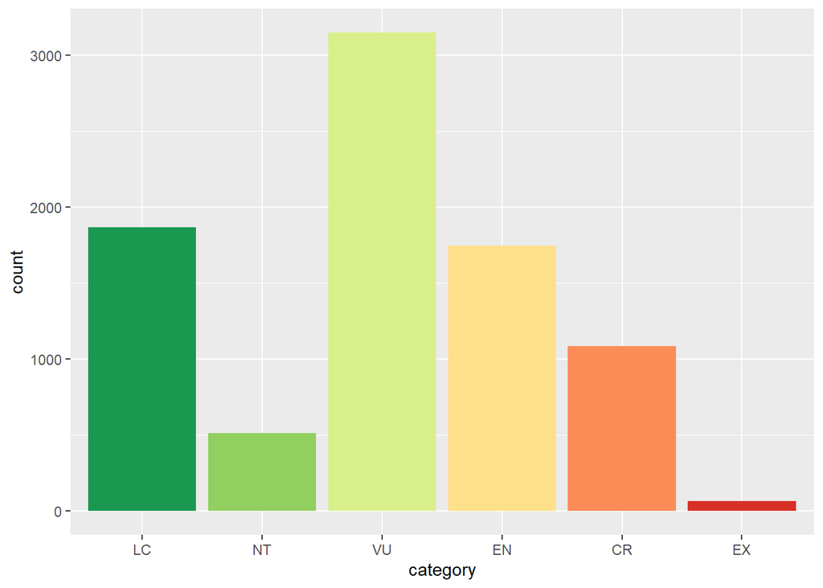

```r
page_stem <- "api/v3/species/page/%s?token=%s"
page_end <- page_stem %>%

  #Number interpreted as a string
  #Page 1, api key
  sprintf(1, api_key)

page_url <- file.path(domain_name, page_end)

#Species from page 1
spp_page1 <- fromJSON(page_url)

#Species dataframe
#also can do spp_page1[["result"]]
spp_df <- spp_page1$result %>%

  mutate(category = factor(category,
                           levels = c("LC", "NT", "VU", "EN", "CR", "EX"))) %>%

  #NA obs will be dropped
  filter(!is.na(category))



#Plot
ggplot(data = spp_df) +
  geom_bar(aes(x = category, fill = category),
           show.legend = FALSE) +
  scale_fill_brewer(palette = "RdYlGn",

                    #Opposite order so extinct is red
                    direction = -1)
```

least concerned, not threatened, vulnerable, endangered, critically endangered, extinct

# Get historical assessments by species name

Time series to see if population getting better over time or not

Not all species have multiple assessments. We’ll look at leatherback sea turtles

/api/v3/species/history/name/:name?token=‘YOUR TOKEN’

```r
hist_stem <- "api/v3/species/history/name/%s?token=%s"
spp <- 'Dermochelys coriacea'
hist_end <- sprintf(hist_stem, spp, api_key)

spp_hist <- fromJSON(file.path(domain_name, hist_end))


#Most of what we want in result
spp_hist_df <- spp_hist$result
```

# Get threats

Threats: `/api/v3/threats/species/name/:name?token='YOUR TOKEN'` Narratives: `/api/v3/species/narrative/:name?token='YOUR TOKEN'`

```r
threats_url <- file.path(domain_name,
                         sprintf('api/v3/threats/species/name/%s?token=%s',
                                 spp, api_key))

#Check human threats to the leatherback seaturtile
spp_thr <- fromJSON(threats_url)$result



#Do same for narrative text by species name
spp_narr <- file.path(domain_name,
                      sprintf('api/v3/species/narrative/%s?token=%s',
                              spp, api_key)) %>%
  fromJSON()


#Explain reasoning behind categorization
spp_narr_df <- spp_narr$result

#Look at threats
spp_narr_df$threats
```

```
## [1] "<p>Threats to Leatherbacks vary in time and space, and in relative impact to populations. Threat categories affecting marine turtles, including Leatherbacks, were described by Wallace <em>et al</em>. (2011) as:</p>  <p>1) Fisheries bycatch: incidental capture of marine turtles in fishing gea…
```

# Map pf species off coast of california

Aquamaps

## Read in the IUCN and AquaMaps data

```r
#read data
iucn_spp_info <- read_csv(here("data/iucn_marine_spp_info_2021-3.csv"))
#iucn_spp_info %>%  unique()

cell_ids <- read_csv(here('data/am_latlong.csv'))
spp_cells <- read_csv(here('data/am_spp_cells.csv'))
spp_ids <- read_csv(here('data/am_spp_ids.csv'))
```

16k+ observatins which are species or sub-populations of species

am_sid = aquamap species ID

Now we want to join all the data together into a dataframe

```r
spp_risk_cells <- spp_cells %>%

  #Join spp_cells with cell_ids, based on loiczid column
  #These are faster than merge, but if large, can use datatable package
  #includes all rows in x and y
  inner_join(cell_ids, by = 'loiczid') %>%

  #Join that with spp_ids, based on am_sid column
  inner_join(spp_ids, by = 'am_sid') %>%

  #Join that with iunc_spp_info
  #Link up columns names that don't match (binomial and sciname are same)
  inner_join(iucn_spp_info, by = c('binomial' = 'sciname'))



threatened_pct_cells <- spp_risk_cells %>%

  #Remove if risk less than 50%
  filter(prob >= 0.5) %>%

  #Category column, look for vu, en, cr, ex
  #Logical test, if in vector T/F, then threatened has T/F
  mutate(threatened = (tolower(cat) %in% c('vu', 'en', 'cr', 'ex'))) %>%

  #Drop data deficient
  filter(cat != 'dd') %>%

  #Group by lon and lat, this order for a reason
  group_by(lon, lat) %>%

  #Summarize % threatened
  summarize(pct_threatened = sum(threatened) / n(),
            spp_richness = n())
```

## Convert cells into raster object

If we wished to do spatial analysis with this lat-long map of percent threatened species, we can convert our grid to a raster. Don’t forget to tell it our CRS, which since we are using lat-long data, we can use WGS84, EPSG code 4326.

Map out spatial distribution of species.

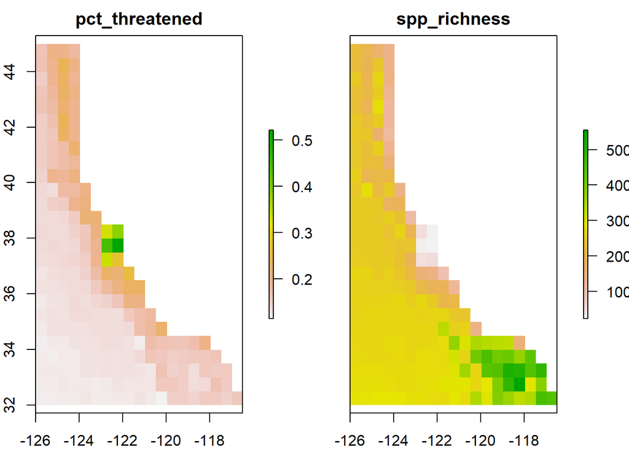

```r
#Convert to raster
spp_risk_rast <- rasterFromXYZ(threatened_pct_cells)
crs(spp_risk_rast) <- 4326

plot(spp_risk_rast)
```

## Plot in ggplot

Use natural earth to pull maps of North America

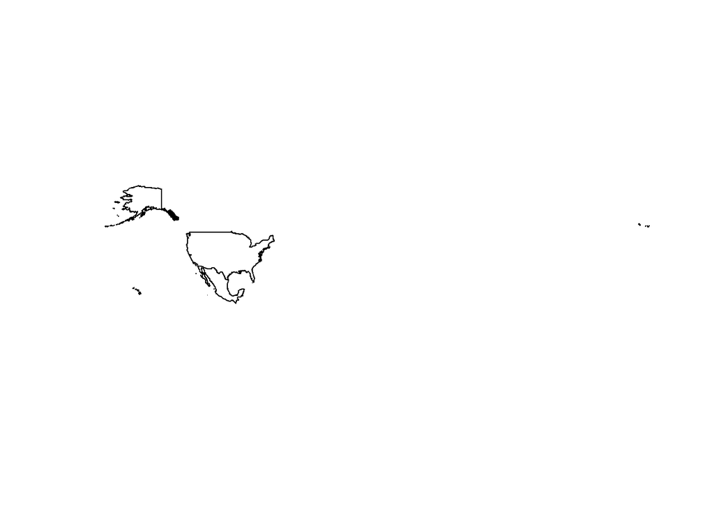

```r
#rnaturalearthdata to know scale

#Scale = 10 if need map to be really detailed
land_sf <- rnaturalearth::ne_countries(scale = 50, ### start with 110
                                       country = c('united states of america', 'mexico'),
                                       #Default in older sp R object file
                                       returnclass = 'sf')

#Check
plot(land_sf %>% select(geometry))
```

```r
st_crs(land_sf)
```

[output not shown]

```r
#Crop land to just region of interest
land_sf_cropped <- land_sf %>%
  st_crop(spp_risk_rast)


#Now go back down to fix plot
```

Doesn’t actual plot raster, but turns it back into a df

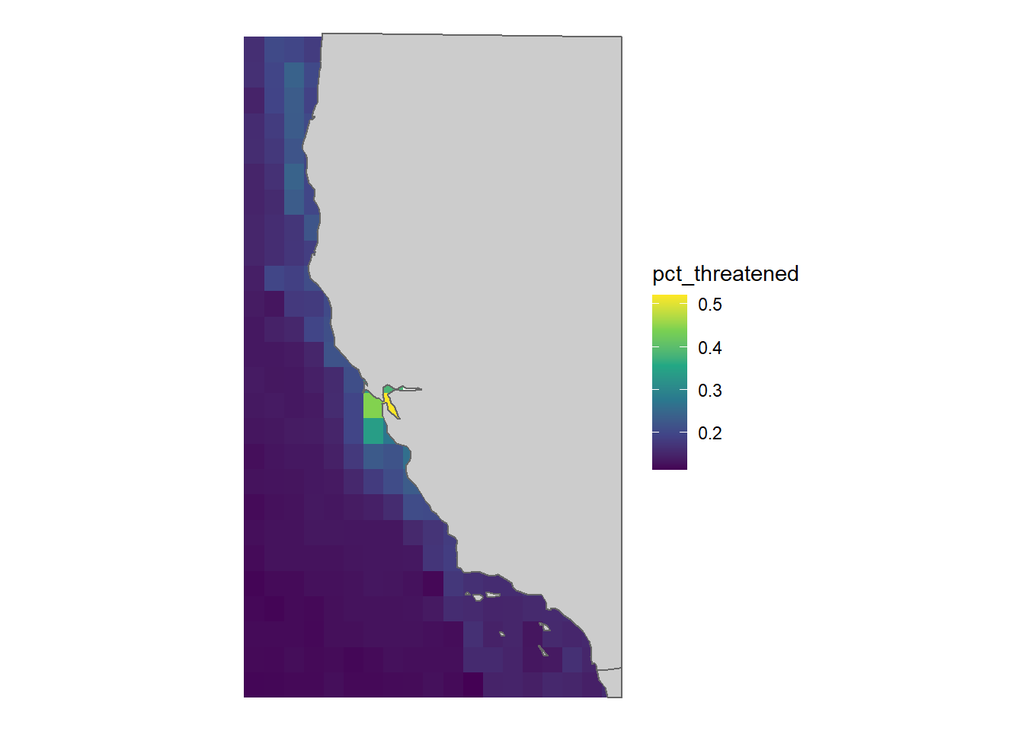

```r
spp_risk_rast_df <- spp_risk_rast %>%

  #Keeps lat long info as well rather than just values
  as.data.frame(xy = TRUE)
### Why does this have different length than threatened_pct_cells?


#Plot of california coast
ggplot(threatened_pct_cells) +
  geom_raster(aes(x = lon, y = lat, fill = pct_threatened)) +

   #fill = spp_richness

  #ADD HERE
  geom_sf(data = land_sf_cropped, fill = 'grey80',
          color = 'grey40', alpha = 1) +
  scale_fill_viridis_c() +
  coord_sf() +
  theme_void()
```

Hot spot of endangeres species located in San Francisco Bay